# Shared latent mortality and annual coral-cover dynamics

Operational validation of programme calibration and net annual change

# Conclusions

The shared latent ecological model is now implemented, but it should **not replace the current prediction ensemble**. It improves MMP transfer, where programme calibration is most needed, but worsens LTMP and manta prediction and trails the weather–RRN BRT overall. It is therefore retained as an MMP calibration and ensemble candidate.

The annual coral-cover target is worth pursuing. A reproducible dataset now contains 3,089 approximately annual transitions, including both gains and losses. Predicting change avoids the denominator instability of relative mortality at low cover and provides post-season coral cover directly. The initial models are useful benchmarks, not yet a production state model:

- a growth/environment linear model slightly improves temporal and forward cover RMSE over persistence;
- a change BRT improves transfer to completely unseen reefs;
- the change BRT captures much of the GBR-wide mean 2024 decline but not its reef-level extremes.

The next dynamic model should separate expected growth from disturbance loss instead of fitting one unrestricted change surface.

# Shared latent mortality model

## What was implemented

One latent ecological logit-mortality state is estimated per reef-event. DHW, thermal history, cover, Acropora, optical environment, rainfall, winds, WQC and cyclone waves enter that state once. Manta tow anchors the ecological scale. LTMP and MMP have separate observation bias, beta precision, and zero/one probabilities.

Programme-specific ecological response loadings were tested and rejected: MMP has only one reef-event paired with another benthic programme, so its loading was not identifiable. The final candidate uses a common ecological scale and regularised programme biases.

Programme overlap available to identify observation layers

| Pattern | Reef-events |
| --- | --- |
| MMP | 32 |
| manta | 84 |
| LTMP | 34 |
| LTMP MMP | 1 |
| LTMP manta | 153 |

There are 153 paired LTMP–manta reef-events. Their mortality correlation is 0.619, with a median absolute difference of 1.5 percentage points. MMP is mostly unpaired, which limits direct identification of its observation bias.

## Predictive comparison

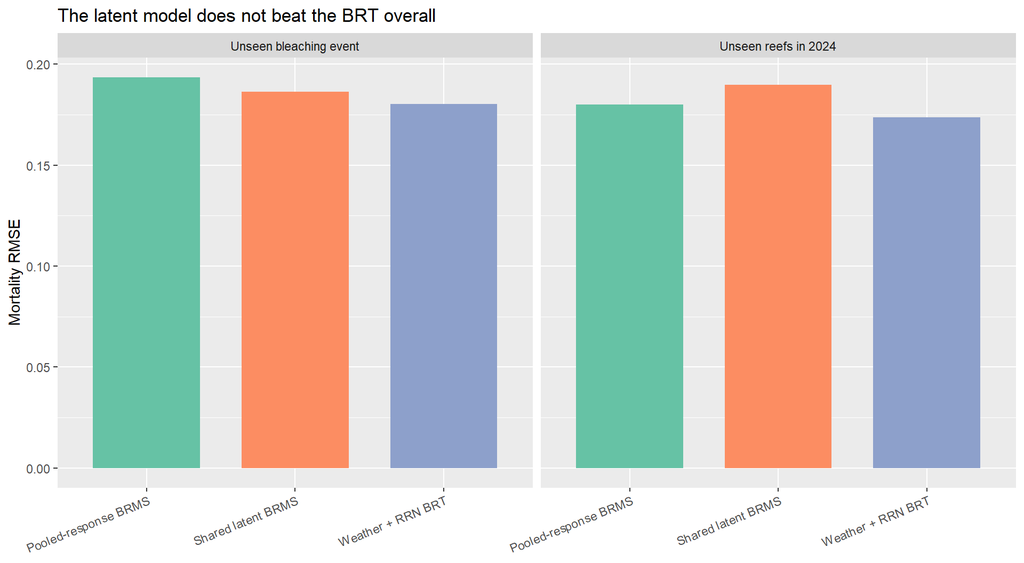

Blocked mortality prediction by programme

| Scheme | Programme | Model | RMSE | MAE | Severe MAE |
| --- | --- | --- | --- | --- | --- |
| Unseen bleaching event | LTMP | Pooled-response BRMS | 0.150 | 0.096 | 0.324 |
| Unseen bleaching event | MANTA | Pooled-response BRMS | 0.158 | 0.113 | 0.275 |
| Unseen bleaching event | MMP | Pooled-response BRMS | 0.324 | 0.232 | 0.347 |
| Unseen reefs in 2024 | LTMP | Pooled-response BRMS | 0.112 | 0.088 | 0.161 |
| Unseen reefs in 2024 | MANTA | Pooled-response BRMS | 0.175 | 0.136 | 0.200 |
| Unseen reefs in 2024 | MMP | Pooled-response BRMS | 0.251 | 0.181 | 0.264 |
| Unseen bleaching event | LTMP | Shared latent BRMS | 0.165 | 0.117 | 0.334 |
| Unseen bleaching event | MANTA | Shared latent BRMS | 0.163 | 0.126 | 0.262 |
| Unseen bleaching event | MMP | Shared latent BRMS | 0.271 | 0.207 | 0.257 |
| Unseen reefs in 2024 | LTMP | Shared latent BRMS | 0.137 | 0.096 | 0.273 |
| Unseen reefs in 2024 | MANTA | Shared latent BRMS | 0.188 | 0.147 | 0.242 |
| Unseen reefs in 2024 | MMP | Shared latent BRMS | 0.247 | 0.197 | 0.263 |
| Unseen bleaching event | LTMP | Weather + RRN BRT | 0.136 | 0.087 | 0.290 |
| Unseen bleaching event | MANTA | Weather + RRN BRT | 0.152 | 0.106 | 0.258 |
| Unseen bleaching event | MMP | Weather + RRN BRT | 0.298 | 0.209 | 0.344 |
| Unseen reefs in 2024 | LTMP | Weather + RRN BRT | 0.115 | 0.087 | 0.156 |
| Unseen reefs in 2024 | MANTA | Weather + RRN BRT | 0.159 | 0.127 | 0.180 |
| Unseen reefs in 2024 | MMP | Weather + RRN BRT | 0.249 | 0.171 | 0.238 |

For unseen events, latent MMP RMSE falls from 0.324 in the previous pooled BRMS to 0.271. LTMP worsens from 0.150 to 0.165 and manta from 0.158 to 0.163. For unseen 2024 reefs, MMP improves only slightly (0.251 to 0.247), while LTMP and manta worsen. The weather–RRN BRT remains best overall at 0.180 unseen-event RMSE and 0.174 unseen-reef RMSE.

The four-chain production fit passes its diagnostic gate (maximum R-hat 1.01, no divergences), but the two-chain screening folds reach R-hat 1.027. The production Bayesian R2 is 0.123. Nineteen PSIS-LOO observations have Pareto `k > 0.7`, so blocked validation is the primary decision evidence.

The production MMP observation bias is negative on the manta-anchored logit scale (-0.677, 95% interval -1.26 to -0.11). LTMP bias is small and uncertain (-0.171, interval -0.38 to 0.06). This explains why calibration helps MMP but adds little for the already well-paired LTMP–manta data.

## Operational use

The production object includes a programme-free prediction path. For any GBR reef-event with the required covariates it returns:

- the population ecological mortality mean, excluding fitted reef effects;
- a process-marginalised mean for a new reef-event;
- 5%, 50% and 95% process intervals generated from a new reef-event effect.

This prevents fitted historical random effects from leaking into GBR-wide maps. Because overall blocked performance is weaker, these predictions should enter ensemble testing rather than being issued alone.

# Annual coral-cover change

## Transition estimand

The annual dataset uses consecutive surveys 240–550 days apart. The response is both next coral cover and absolute percentage-point change:

[ C = 100(C_{t+1} - C_t). ]

Unlike the bleaching-mortality table, gains are retained and no observations are removed because another disturbance is recorded. Current cover, previous change, interval duration, Acropora composition, DHW, WQC, cyclone waves and COTS are all available as candidate predictors. Acropora fallbacks use only the baseline year or the preceding two years.

Annual coral-cover transition dataset

| Programme | transitions | reefs | Positive changes | Negative changes | Median interval (days) |
| --- | --- | --- | --- | --- | --- |
| ltmp | 867 | 78 | 490 | 377 | 374.0 |
| manta | 1416 | 145 | 748 | 668 | 370.5 |
| mmp | 806 | 26 | 436 | 368 | 361.0 |

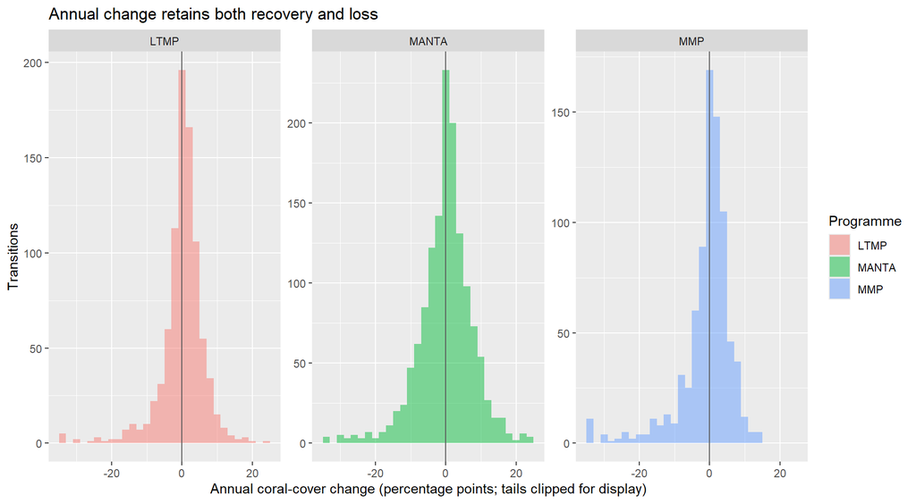

Of the 3,089 transitions, 54.2% increase and 45.7% decline. The median change is +0.44 percentage points, with a 5th–95th percentile range of approximately -12.9 to +9.8 points.

## Why absolute change is complementary

Change distribution by starting coral cover

| pre_cover_bin | transitions | median_absolute_change_pp | relative_change_q05 | relative_change_q50 | relative_change_q95 |
| --- | --- | --- | --- | --- | --- |
| <5% | 83 | 0.97 | -0.48 | 0.27 | 1.43 |
| 5-10% | 233 | 1.76 | -0.35 | 0.12 | 0.72 |
| 10-20% | 855 | 2.42 | -0.33 | 0.06 | 0.65 |
| 20-40% | 1341 | 3.96 | -0.42 | 0.00 | 0.38 |
| >40% | 577 | 5.14 | -0.54 | -0.03 | 0.20 |

Below 5% initial cover, the 5th–95th percentile relative-change range is approximately -48% to +143%. Absolute change remains on the interpretable percentage-point scale. Absolute change should therefore complement, not replace, event-attributable relative mortality: the two answer different ecological questions.

## Initial predictive benchmarks

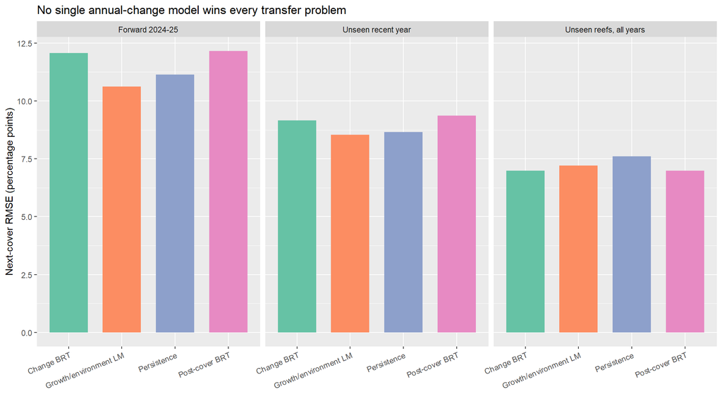

Annual transition validation

| Scheme | Model | Cover RMSE (pp) | Change MAE (pp) | Change bias (pp) | Direction accuracy | Severe-loss MAE (pp) |
| --- | --- | --- | --- | --- | --- | --- |
| Forward 2024-25 | Change BRT | 12.06 | 8.52 | -0.90 | 54.9% | 17.93 |
| Unseen recent year | Change BRT | 9.16 | 6.18 | 0.76 | 55.8% | 17.36 |
| Unseen reefs, all years | Change BRT | 6.98 | 4.79 | 0.17 | 60.6% | 13.73 |
| Forward 2024-25 | Growth/environment LM | 10.62 | 7.02 | -3.36 | 55.8% | 19.08 |
| Unseen recent year | Growth/environment LM | 8.54 | 5.93 | 0.63 | 53.5% | 16.81 |
| Unseen reefs, all years | Growth/environment LM | 7.21 | 5.02 | 0.05 | 57.5% | 14.88 |
| Forward 2024-25 | Persistence | 11.13 | 7.03 | -4.08 | 0.6% | 21.00 |
| Unseen recent year | Persistence | 8.66 | 5.57 | -0.29 | 0.2% | 19.71 |
| Unseen reefs, all years | Persistence | 7.61 | 4.97 | -0.29 | 0.1% | 18.40 |
| Forward 2024-25 | Post-cover BRT | 12.15 | 8.62 | -1.15 | 53.4% | 18.43 |
| Unseen recent year | Post-cover BRT | 9.36 | 6.33 | 0.91 | 55.6% | 17.29 |
| Unseen reefs, all years | Post-cover BRT | 6.99 | 4.85 | 0.14 | 59.9% | 13.68 |

For forward prediction of 2024–25, the growth/environment model improves next-cover RMSE from 11.13 points under persistence to 10.62. For recent leave-one-year-out prediction it improves 8.66 to 8.54. For reefs withheld from every year, the change BRT is best at 6.98 points versus 7.61 for persistence.

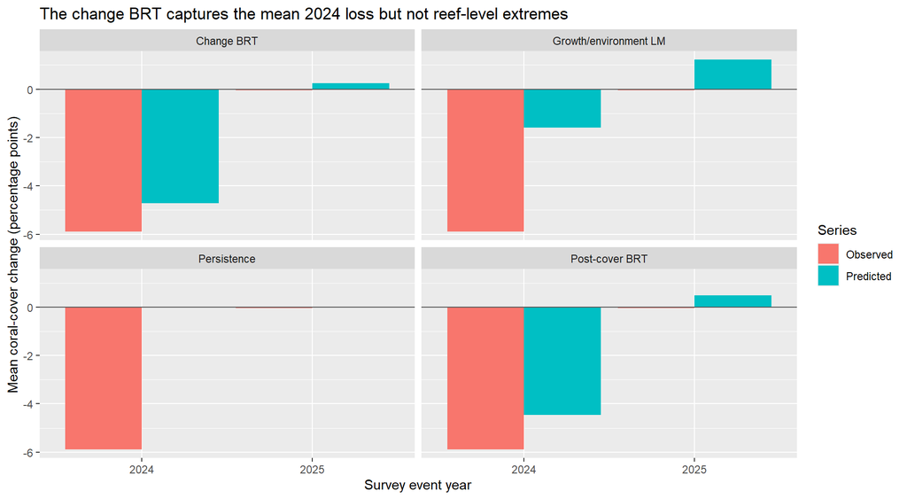

Observed mean change in 2024 is -5.89 points. The forward change BRT predicts -4.71, compared with -1.60 for the growth model and zero for persistence. Nevertheless, its individual 2024 RMSE is 13.4 points; the growth model is better at 11.6. The model recognises an event-wide loss but allocates it poorly among reefs.

## Influential predictors and residual priorities

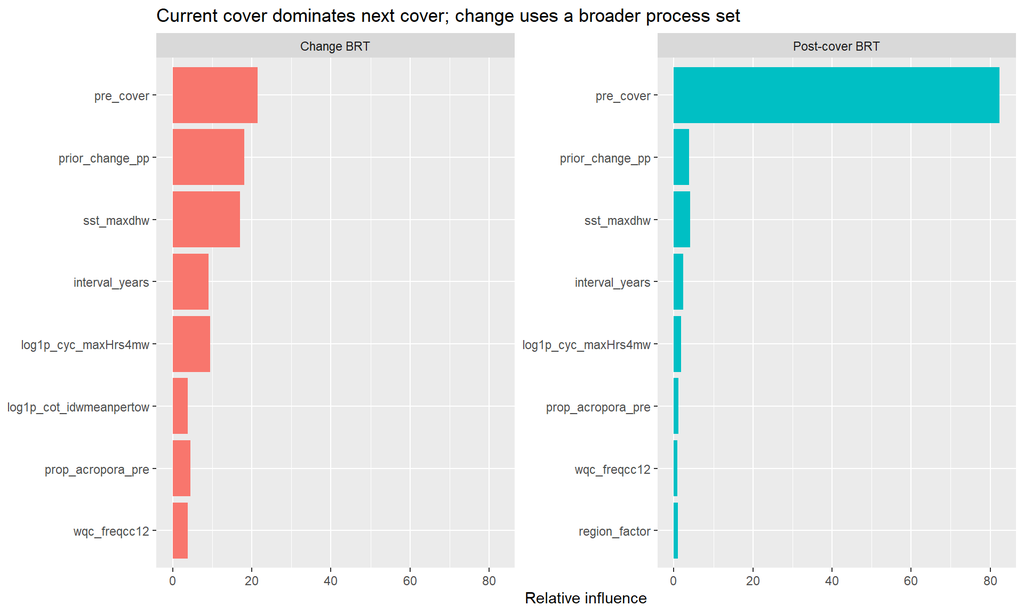

Current cover contributes 82% of post-cover BRT influence. In the change BRT, current cover (21%), previous change (18%), DHW (17%), cyclone waves (9%) and interval length (9%) dominate. Acropora contributes 4.4%, WQC 3.8% and COTS 3.8%. These are predictive influences, not causal partitions.

Largest forward 2024-25 change-BRT misses

| Reef | Programme | Year | DHW | Starting cover | Observed change (pp) | Predicted change (pp) | Error (pp) | Disturbance |
| --- | --- | --- | --- | --- | --- | --- | --- | --- |
| Snapper Reef (16-006) | MMP | 2024 | 6.87 | 57.9% | -57.9 | -5.6 | -52.3 | Jasper Cyclone Jasper, flood waters at 2.0 m only, coral bleaching at 5.0 m only \| flood waters, Cyclone Jasper |
| Snapper Reef (16-006) | MMP | 2024 | 6.87 | 50.3% | -50.3 | -5.3 | -45.0 | Jasper Cyclone Jasper, flood waters at 2.0 m only, coral bleaching at 5.0 m only \| flood waters, Cyclone Jasper |
| North Direction Reef (14-143) | MANTA | 2024 | 6.23 | 58.4% | -40.2 | -4.0 | -36.2 | DHW 6.23 aerial bl 5 coral bleaching |
| Rebe Reef (19-209) | MANTA | 2024 | 10.34 | 46.6% | 4.3 | -29.9 | 34.2 | NA |
| Slate Reef (19-159) | MANTA | 2024 | 8.61 | 52.8% | 4.6 | -28.8 | 33.5 | NA |
| One Tree Island Reef (23-055a) | LTMP | 2024 | 11.61 | 64.7% | -45.6 | -13.2 | -32.4 | DHW 11 coral bleaching, coral disease |
| Linnet Reef (14-126) | MANTA | 2024 | 6.68 | 42.8% | -30.6 | 0.7 | -31.3 | DHW 6.73 coral bleaching |
| Stingaree Reefs (17-053) | MMP | 2025 | 3.75 | 44.0% | -29.9 | 1.1 | -31.0 | flood waters at 2.0 m only |
| U/N Reef (20-104) | MANTA | 2024 | 5.56 | 16.2% | 23.3 | -7.3 | 30.6 | NA |
| Broomfield Reef (23-048) | LTMP | 2024 | 11.61 | 57.5% | -39.6 | -10.2 | -29.4 | Aerial bl 5 2024 DHW 11.6 coral bleaching, unknown storm |
| Mackay Reef (16-015) | MANTA | 2024 | 3.77 | 42.5% | -26.0 | 1.7 | -27.8 | DHW 4.03 coral bleaching, Cyclone Jasper, flood waters |
| Slate Reef (19-159) | MANTA | 2024 | 8.61 | 61.9% | -9.1 | -36.3 | 27.2 | DHW 8.61 coral bleaching |
| Slate Reef (19-159) | LTMP | 2024 | 8.61 | 46.1% | -6.1 | -33.0 | 27.0 | coral bleaching |
| U/N Reef (19-138) | LTMP | 2024 | 5.81 | 43.4% | 6.9 | -20.0 | 26.9 | NA |
| Rebe Reef (19-209) | MANTA | 2024 | 10.34 | 61.6% | -15.0 | -41.3 | 26.3 | DHW 9.3 to 11.1 coral bleaching |

Snapper, North Direction, One Tree Island, Linnet, Broomfield and corrected Mackay are among the large 2024 misses. Some reefs also show observed gains where the model predicts event loss. This is the correct residual set for examining fine-scale exposure, taxonomic recovery state, survey timing and unrecorded disturbance.

# Pipeline decision

1. Keep the shared latent model as an MMP calibration/ensemble candidate, not the sole operational mortality model.
2. Retain both relative bleaching mortality and annual absolute cover change.
3. Use the annual transition table as the input to a formal dynamic model with separate growth and disturbance-loss components.
4. Constrain growth by current cover and available space; allow DHW, freshwater/WQC, cyclone waves, COTS and community composition to affect losses.
5. Preserve programme observation layers and integrate unknown reef/year effects for GBR-wide forecasts.
6. Require improvement over persistence in forward years and over the change BRT for unseen reefs before operational promotion.